# Generalized Linear Regression in NIMBLE

Adam B. Smith

2023-10-13

This tutorial walks you through how to do generalized linear regression. Specifically, we will explore logistic regression (where the response is 1s and 0s). We’ll use simulated data for which we know the “true” answers.

Again, the [online manual](https://r-nimble.org/html_manual/cha-welcome-nimble.html) for `nimble` is very useful. The [main webpage](https://r-nimble.org/) for `nimble` also links to a host of useful information.

## Setup

```r
library(nimble) # the workhorse
```

```r
library(coda) # for model diagnostics
library(bayesplot) # for graphing
```

## Create some fake data

We need to create a response vector that has just 1s and 0s. We’ll do this by simulating some data, `y`, that responds linearly to `x`. Values of `y` will follow a normal distribution. We’ll then use the inverse logit transform to convert `y` to the range (0, 1) (like a probability). Finally, we’ll impose a probabilistic threshold to convert these values to 1s and 0s.

```r
N <- 100 # number of data points
x <- rnorm(N) # predictor
beta0 <- 1 # intercept
beta1 <- 1.2 # slope
sigma <- 0.8 # variation around trendline

noise <- rnorm(N, mean = 0, sd = sigma)
y <- beta0 + beta1 * x + noise

# function for inverse logit
invlogit <- function(x) exp(x) / (1 + exp(x))

# convert to range of (0, 1)
ytrans <- invlogit(y)

# convert to 0/1 probabilistically
ybinary <- as.integer(runif(N) < ytrans)
```

Let’s look at the data through the transformation process.

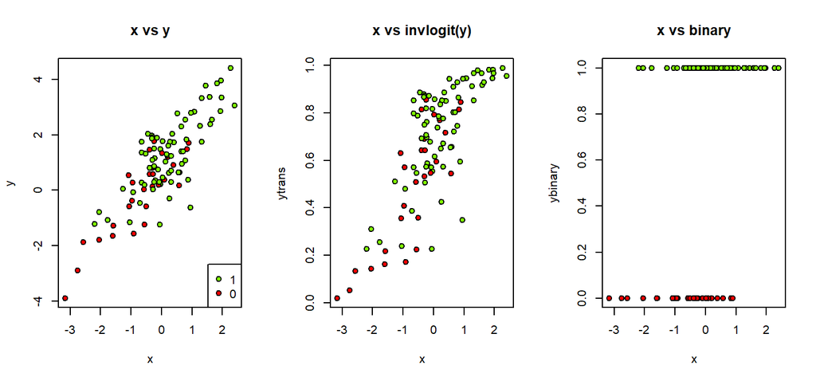

```r
par(mfrow = c(1, 3))

# x vs y
bg <- ifelse(ybinary == 1, "chartreuse", "red")
plot(x, y, pch = 21, bg = bg, main = 'x vs y')

legend('bottomright', legend = c(1, 0), pt.bg = c('chartreuse', 'red'), pch = 21)

# x vs inverse-logit transform of y
plot(x, ytrans, pch = 21, bg = bg, main = 'x vs invlogit(y)')

# x vs binary y
plot(x, ybinary, pch = 21, bg = bg, main = 'x vs binary')
```

Finally, we’ll rescale our predictor (`x`) to have a 0 mean and unit variance.

```r
x_scaled <- scale(x) # output is a 1-column matrix
x_scaled <- c(x_scaled) # convert back to a vector
```

## Organize data into formats needed by `nimble`

```r
data <- list(ybinary = ybinary)

constants <- list(
    x_scaled = x_scaled,
    N = N
)

# two sets of initialization values, one for correct and one for incorrect model
inits <- list(
    beta0_hat = 0,
    beta1_hat = 0,
    y_est = ybinary
)
```

## What we’re about to do

If we were interested in the relationship between `y` and `x` (neither of them transformed), we could use a linear model like this:

$$y_i = \beta_0 + \beta_1 x_i +
\epsilon_i$$

where, together, all the $\epsilon$s for all $i$ follow a normal distribution with a mean of 0 and standard deviation of $\sigma$. Ergo,

$$y = \beta_0 + \beta_1 x + N(0,
\sigma)$$
.

We’ve learned that this can be written like:

$$y \sim N(\beta_0 + \beta_1 x,
\sigma)$$

meaning that`y` has a normal distribution that has a mean given by the estimated regression line.

For binary (logistic) regression, though, we have 0s and 1s, which cannot be described by a normal distribution. Rather, we use the Bernoulli distribution, which returns 0 or 1, and takes as an argument $\psi$, the probability that the value is 1. A Bernoulli distribution is essentially a single coin toss that returns heads or tails (or, equivalently, a binomial distribution with just one trial). So, we have:

$$ybinary_i \sim Bern(\psi_i)$$

We can now write an equation for $\psi$, as a function of things we think drive the probability of getting a 1 or 0.

$$logit(\psi) = \beta_0 + \beta_1
x$$

Note that: * We use the `logit()` function to transform $\psi$, which has the range (0, 1) to unbounded values (i.e., between negative and positive infinity), just like a normal distribution.

- The right hand side is our linear regression equation from before. We’re positing that the probability of getting a 1 or 0 depends on `x` and the $\beta$ coefficients.
- We don’t include the $N(0, \sigma)$ part in the linear predictor. That’s because the randomness is taken account of by the $Bern()$ distribution function.

NIMBLE has functions for the Bernoulli distribution and for the logit transform.

## Writing the `nimble` model

In addition to specifying our model, we will also ask NIMBLE to do a little extra, interesting work. Let’s say we want to find the mean value of `ybinary`. This is easy to do using `mean(ybinary)`, but let’s also say we want to calculate the mean of the values of `ybinary` that NIMBLE *thinks* the values should be, based on its model of `ybinary`. We can then compare `mean(ybinary)` with NIMBLE’s estimate of the mean of `ybinary`.

```r
code <- nimbleCode({

    # likelihood of each datum
    for (i in 1:N) {

        # note the "sd = " part!
        ybinary[i] ~ dbern(psi[i])
        logit(psi[i]) <- beta0_hat + beta1_hat * x_scaled[i]

    }

    # likelihoods of priors
    # beta0_hat and beta1_hat: "broad" normals
    # sigma_hat: uniform >0 (after Gelman 2006 Bayesian Analysis)

    beta0_hat ~ dnorm(0, sd = 10)
    beta1_hat ~ dnorm(0, sd = 10)

    # simulate the data and calculate an auxillary variable
    # this does not affect the likelihood
    for (j in 1:N) {
        y_est[j] ~ dbern(psi[j])
    }
    y_est_mean <- mean(y_est[1:N])

})
```

## Process the model code

First, check the code for errors and do some other arcane things.

```r
# correct model
model <- nimbleModel(
    code = code, # our model
    constants = constants, # constants
    data = data, # data
    inits = inits, # initialization values
    check = TRUE, # any errors?
    calculate = FALSE
)
```

```
## Defining model
```

```
## Building model
```

```
## Setting data and initial values
```

```
## Checking model sizes and dimensions
```

```
##   [Note] This model is not fully initialized. This is not an error.
##          To see which variables are not initialized, use model$initializeInfo().
##          For more information on model initialization, see help(modelInitialization).
```

```
## Checking model calculations
```

```r
model$initializeInfo()
```

```
##   [Note] All model variables are initialized.
```

```r
model$calculate()
```

```
## [1] -145.0725
```

We now create an MCMC “configuration” for the model. We also need to tell it what variables to keep track of.

```r
# corect model
monitors <- c('beta0_hat', 'beta1_hat', 'y_est_mean')

conf <- configureMCMC(
    model,
    monitors = monitors,
    print = TRUE,
    enableWAIC = FALSE # Watanabe's AIC
)
```

```
## ===== Monitors =====
## thin = 1: beta0_hat, beta1_hat, y_est_mean
## ===== Samplers =====
## RW sampler (2)
##   - beta0_hat
##   - beta1_hat
## posterior_predictive sampler (100)
##   - y_est[]  (100 elements)
```

Lastly, we “build” and compile the model.

```r
build <- buildMCMC(conf)
compiled <- compileNimble(model, build)
```

```
## Compiling
##   [Note] This may take a minute.
##   [Note] Use 'showCompilerOutput = TRUE' to see C++ compilation details.
```

## Run the MCMC sampler!

```r
chains <- runMCMC(
    compiled$build,
    niter = 1100, # iterations
    nburnin = 100, # burn-in
    thin = 1, # thinning rate
    nchains = 4, # number of chains
    inits = inits, # initialization values
    progressBar = TRUE,
    samplesAsCodaMCMC = TRUE, # for using coda package for plots
    summary = TRUE, # calculate summaries across chains
    WAIC = FALSE, # Watanabe's AIC
    perChainWAIC = FALSE
)
```

```
## running chain 1...
```

```
## |-------------|-------------|-------------|-------------|
## |-------------------------------------------------------|
```

```
## running chain 2...
```

```
## |-------------|-------------|-------------|-------------|
## |-------------------------------------------------------|
```

```
## running chain 3...
```

```
## |-------------|-------------|-------------|-------------|
## |-------------------------------------------------------|
```

```
## running chain 4...
```

```
## |-------------|-------------|-------------|-------------|
## |-------------------------------------------------------|
```

# Examine output

Let’s look at the summary of our estimates:

```r
chains$summary$all.chains
```

```
##                Mean   Median    St.Dev. 95%CI_low
## beta0_hat  1.149478 1.135836 0.25992788 0.6799428
## beta1_hat  1.124034 1.104364 0.30756719 0.5243410
## y_est_mean 0.717690 0.720000 0.05687858 0.6000000
##            95%CI_upp
## beta0_hat   1.688460
## beta1_hat   1.767315
## y_est_mean  0.820000
```

```r
# correct values
c(beta0 = beta0, beta1 = beta1, y_mean = mean(y))
```

```
##     beta0     beta1    y_mean
## 1.0000000 1.2000000 0.9136189
```

These are our estimates for the parameters of interest.

# Model diagnostics

## Chain convergence

First, calculate the the Gelman-Rubin diagnostic values for assessing convergence of our chains:

```r
gelman.diag(chains$samples)
```

```
## Potential scale reduction factors:
##
##            Point est. Upper C.I.
## beta0_hat        1.01       1.02
## beta1_hat        1.00       1.00
## y_est_mean       1.01       1.02
##
## Multivariate psrf
##
## 1.01
```

In my run, these are all <1.1 so look OK.

## Chain mixing, convergence, and parameter estimates

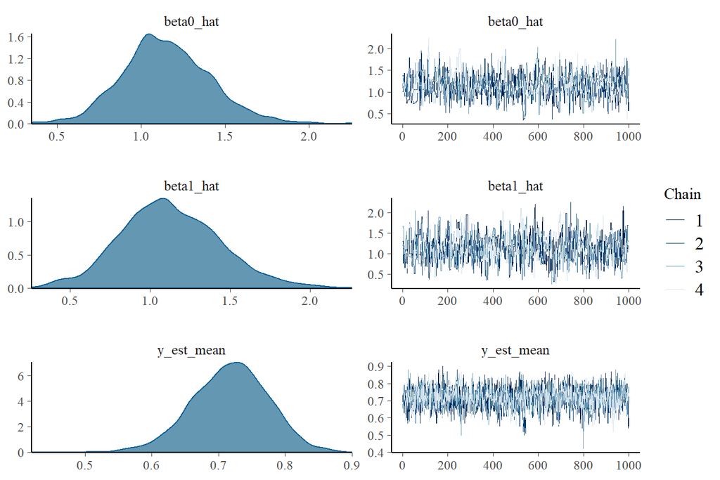

```r
mcmc_combo(chains$samples)
```

The chains look well-mixed in the trace plots (rihgt column), but the “lumpy” appearance of the posterior (the plots on the left) suggests that we should probably run the model for more iterations. But we’ll live with this for now.

### The easier way

Note that we could have gotten a logistic regression simply by using `glm()` to do a “standard” generalized linear regression:

```r
model <- glm(ybinary ~ x_scaled, family = binomial())
coefficients(model)
```

```
## (Intercept)    x_scaled
##    1.135555    1.087256
```

*Finis!*